# JHU 06 Course Project part 2 - ToothGrowth R dataset

Kamran Haroon

June 22, 2015

### Overview

This report is part submission for the class project in Statistical Inference - a course in the John Hopkins University Data Science specialization on Coursera. As per the project webpage, we are required to:

1. Load the ToothGrowth data and perform some basic exploratory data analyses
2. Provide a basic summary of the data.
3. Use confidence intervals and/or hypothesis tests to compare tooth growth by supp and dose. (Only use the techniques from class, even if there’s other approaches worth considering)
4. State your conclusions and the assumptions needed for your conclusions.

The data is the result of measuring the affect of different dosage amounts of Vitamin C on the length of odontoblasts (teeth) of ten guinea pigs. There are two supplement types of Vitamin C tested, Orange Juice and Ascorbic Acid, and they are given in three three different milligram dosage amount, 0.5, 1.0, and 2.0. The report goes through the process of cleansing the dataset, conducting exploratory analysis, and a completing statistical inference around different categorizations to the length of the teeth.

```r
suppressWarnings(library(ggplot2))
suppressMessages(library(data.table))
library(grid)
```

### Data Cleansing

```r
# load data and make column names meaningful
data1 <- data.table(ToothGrowth)
setnames(data1, c('len', 'supp', 'dose'), c('Length', 'Supplement', 'Dose'))

# add 'Dosage'and set the join key
data1 <- data1[,Dosage:=sapply(as.character(data1$Dose), function(x) as.factor(switch(x, '0.5'='SM', '1'='MD', '2'='LG')))]
setkey(data1, Supplement, Dosage)
head(data1, 1)
```

```
##    Length Supplement Dose Dosage
## 1:   15.2         OJ  0.5     SM
```

### Exploratory Analysis

The following result sets are two a simple exploratory methods to understand the content and the structure of the data.table that we will continue to analyze in later sections of the report.

```r
summary(data1)
```

```
##      Length      Supplement      Dose       Dosage
##  Min.   : 4.20   OJ:30      Min.   :0.500   SM:20
##  1st Qu.:13.07   VC:30      1st Qu.:0.500   MD:20
##  Median :19.25              Median :1.000   LG:20
##  Mean   :18.81              Mean   :1.167
##  3rd Qu.:25.27              3rd Qu.:2.000
##  Max.   :33.90              Max.   :2.000
```

```r
str(data1)
```

```
## Classes 'data.table' and 'data.frame':   60 obs. of  4 variables:
##  $ Length    : num  15.2 21.5 17.6 9.7 14.5 10 8.2 9.4 16.5 9.7 ...
##  $ Supplement: Factor w/ 2 levels "OJ","VC": 1 1 1 1 1 1 1 1 1 1 ...
##  $ Dose      : num  0.5 0.5 0.5 0.5 0.5 0.5 0.5 0.5 0.5 0.5 ...
##  $ Dosage    : Factor w/ 3 levels "SM","MD","LG": 1 1 1 1 1 1 1 1 1 1 ...
##  - attr(*, ".internal.selfref")=<externalptr>
##  - attr(*, "sorted")= chr  "Supplement" "Dosage"
```

To further conduct the exploratory analysis, we can plot Length against both Dosage and Supplement. When we do this we see that the larger the Dosage, the longer the tooth Length. However, it is slightly unclear as to which supplement is more effective, Orange Juice OJ or Ascorbic Acid VC.

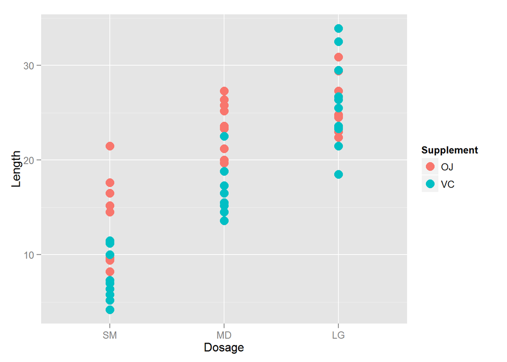

```r
# plot 1
g1 <- ggplot(data1, aes(x=Dosage, y=Length))
g1 <- g1+geom_point(aes(color=Supplement), size=4)
# plot 2
g2 <- ggplot(data1, aes(x=Supplement,y=Length))
g2 <- g2+geom_point(aes(color=Dosage),size=4)
# plot together
print(g1)
```

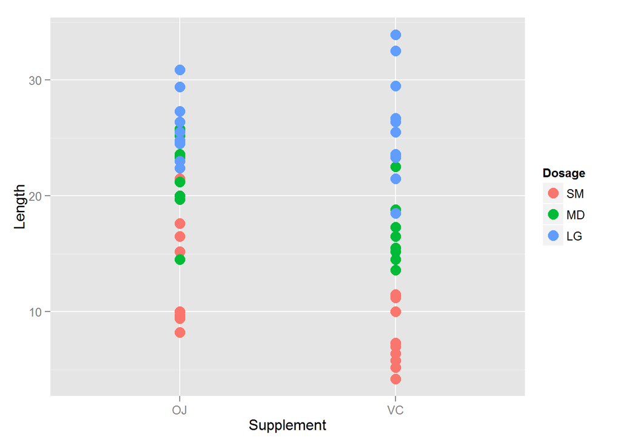

```r
print(g2)
```

### Confidence Interval Testing

In order to understand Vitamin C’s affect on tooth growth, we will conduct the following confidence interval testing scenarios:

Dosage Alone Supplement Alone Supplement by Each Dosage For each of the comparisons, we will subset dt appropriately and utilize the t.test R function to determine each scenarios confidence interval, subset means, and p-value.

Compare Dosage Alone

```r
t1<-subset(data1,Dosage=='SM')$Length
t2<-subset(data1,Dosage=='MD')$Length
t<-t.test(t1,t2,paired=FALSE,var.equal=FALSE)
t$conf.int[1:2]
```

```
## [1] -11.983781  -6.276219
```

If we increase the Vitamin C dose from 0.5 to 1.0 milligrams, the confidence interval does not contain zero, so we can reject the null hypothesis that this dose increase does not increase tooth length.

```r
t1<-subset(data1,Dosage=='MD')$Length
t2<-subset(data1,Dosage=='LG')$Length
t<-t.test(t1,t2,paired=FALSE,var.equal=FALSE)
t$conf.int[1:2]
```

```
## [1] -8.996481 -3.733519
```

Next, if we increase the Vitamin C dose from 1.0 to 2.0 milligrams, the confidence interval againg does not contain zero, so we can reject the null hypothesis that this dose increase does not increase tooth length.

In both of these scenarios, an increased dose amount leads to an increased tooth length.

Compare Supplement Alone

```r
t1<-subset(data1,Supplement=='VC')$Length
t2<-subset(data1,Supplement=='OJ')$Length
t<-t.test(t1,t2,paired=FALSE,var.equal=FALSE)
t$p.value
```

```
## [1] 0.06063451
```

```r
t$conf.int[1:2]
```

```
## [1] -7.5710156  0.1710156
```